# Comprehensive Random Analysis of Covid-19

2023-01-24

This is a response to Adeline document about using random forest to explore the factors related to Covid-19. We liked the ideas included and hoped to extend it by exploring specific hypothesis about the question.

Motivation: Adeline document cheeked to answer the importance of wastewater covariants by using a random forest on the difference.logerence of N1 and cases. This is mathematicaly equivalent on running the forest on the residuals of the model Case = avg_sars_cov2_conc. This creates a problem because this difference.logerence remains strongly correlated with both the case signal and the wastewater signal meaning that large devience is more explained by devience in two source vectors then in the need for another variable. Bellow shows both the correlation and scatter plots. we hope to show two rigorus hypothesis that don’t have the same limitations.

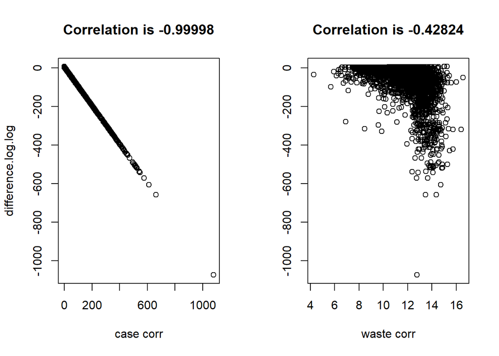

```r
title_prep <- function(x)paste("Correlation is", round(x,5))

case_cor <- cor(data.select.1$difference.log, data.select.1$case_rate, use = "na.or.complete")
waste_cor <- cor(data.select.1$difference.log, data.select.1$avg_sars_cov2_conc, use = "na.or.complete")

{
layout(matrix(1:2, 1, 2, byrow = TRUE))
plot(x = data.select.1$case_rate, y = data.select.1$difference.log,
     xlab = "case corr", ylab = "difference.log.log", main = title_prep(case_cor))
plot(x = log(data.select.1$avg_sars_cov2_conc + 1), y = data.select.1$difference.log,
     xlab = "waste corr", ylab = "", main = title_prep(waste_cor))
}
```

Hypothisis one: there is a linear relationship between N1 and cases. the covariates change the intercept of the relationship but there is always a base relationship.

A quick look at the data makes this look plausible with a thick cloud that looks like it could be explained by many perpendicular linear models. furthermore the residuals look normal which helps support that conclusion.

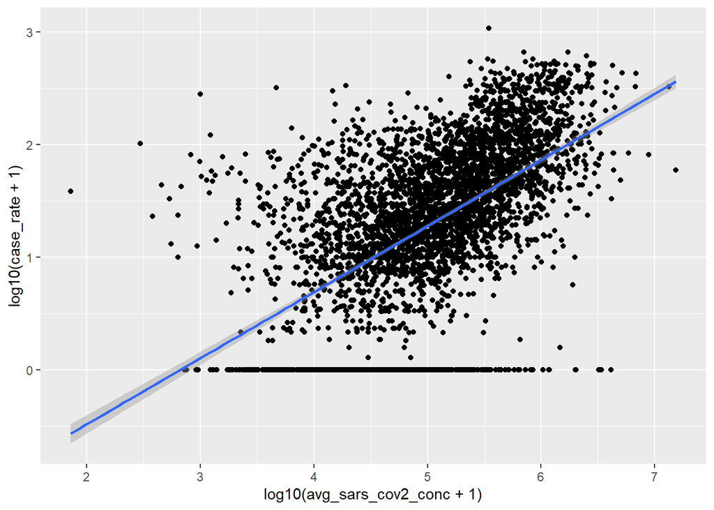

```r
data.select.2.sc <- data.select.1
#data.select.2.sc
data.select.2.sc%>%
  ggplot(aes(x = log10(avg_sars_cov2_conc + 1), y = log10(case_rate + 1)))+
  geom_point()+
  geom_smooth(method = "lm")
```

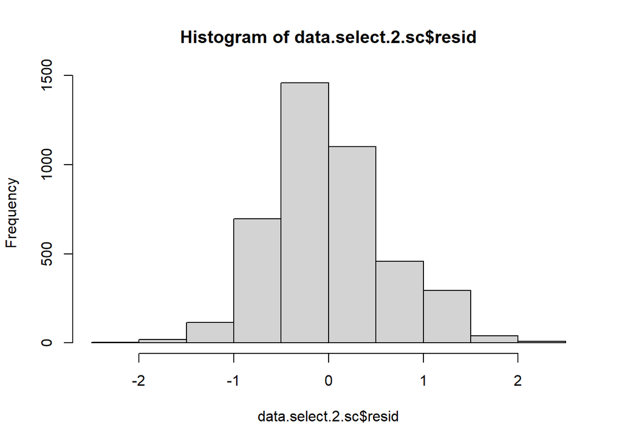

```r
lm_model = lm(log10(case_rate + 1) ~ log10(avg_sars_cov2_conc + 1),
              data = data.select.2.sc,
              na.action = na.exclude)

data.select.2.sc$resid = -resid(lm_model)

  #(data.select.1$case_rate -  coef(lm_model)[1])/data.select.1$sars_cov2_adj_load

hist(data.select.2.sc$resid)
```

```r
base_df <- data.select.2.sc%>%
  rename(conf_case = case_rate)
```

This method also has a much smaller correlation of the two source vectors giving results much better at capturing the important covariants

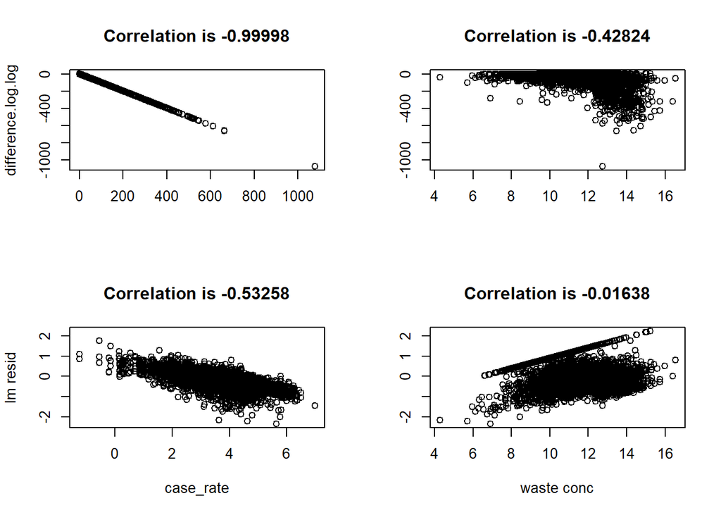

```r
resid_case_cor <- cor(data.select.2.sc$resid,
                      data.select.2.sc$case_rate,
                      use = "na.or.complete")
resid_waste_cor <- cor(data.select.2.sc$resid,
                       data.select.2.sc$avg_sars_cov2_conc,
                       use = "na.or.complete")

{
layout(matrix(1:4, 2, 2, byrow = TRUE))
plot(x = data.select.2.sc$case_rate, y = data.select.2.sc$difference.log,
     xlab = "", ylab = "difference.log.log", main = title_prep(case_cor))
plot(x = log(data.select.2.sc$avg_sars_cov2_conc), y = data.select.2.sc$difference.log,
     xlab = "", ylab = "", main = title_prep(waste_cor))
plot(x = log(data.select.2.sc$case_rate), y = data.select.2.sc$resid,
     xlab = "case_rate", ylab = "lm resid", main = title_prep(resid_case_cor))
plot(x = log(data.select.2.sc$avg_sars_cov2_conc), y = data.select.2.sc$resid,
     xlab = "waste conc", ylab = "", main = title_prep(resid_waste_cor))
}
```

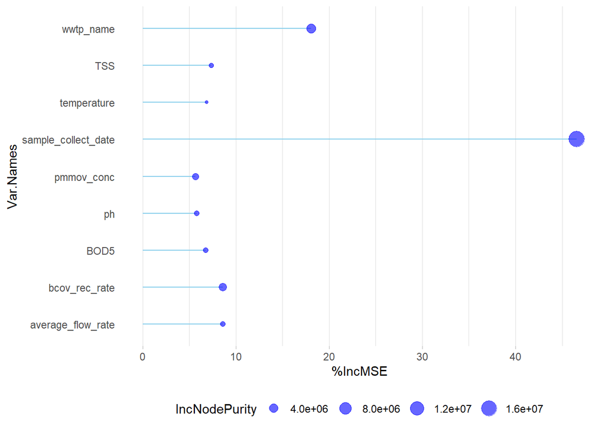

```r
imp_ploting <- function(temp_mod){
  ImpData <- as.data.frame(randomForest::importance(temp_mod))
  ImpData$Var.Names <- row.names(ImpData)


ggplot(ImpData, aes(x=Var.Names, y=`%IncMSE`)) +
  geom_segment( aes(x=Var.Names, xend=Var.Names, y=0, yend=`%IncMSE`), color="skyblue") +
  geom_point(aes(size = IncNodePurity), color="blue", alpha=0.6) +
  theme_light() +
  coord_flip() +
  theme(
    legend.position="bottom",
    panel.grid.major.y = element_blank(),
    panel.border = element_blank(),
    axis.ticks.y = element_blank())
}


library(randomForest)
library(randomForestExplainer)

adeline_df <- data.select.2.sc%>%
  select(-case_rate, -avg_sars_cov2_conc, - resid)%>%
  select(sample_collect_date, everything())


ade_mod <- randomForest(difference.log ~ ., data = adeline_df, ntree=100,
                    na.action = na.roughfix, importance=TRUE, keep.inbag=TRUE)
imp_ploting(ade_mod)
```

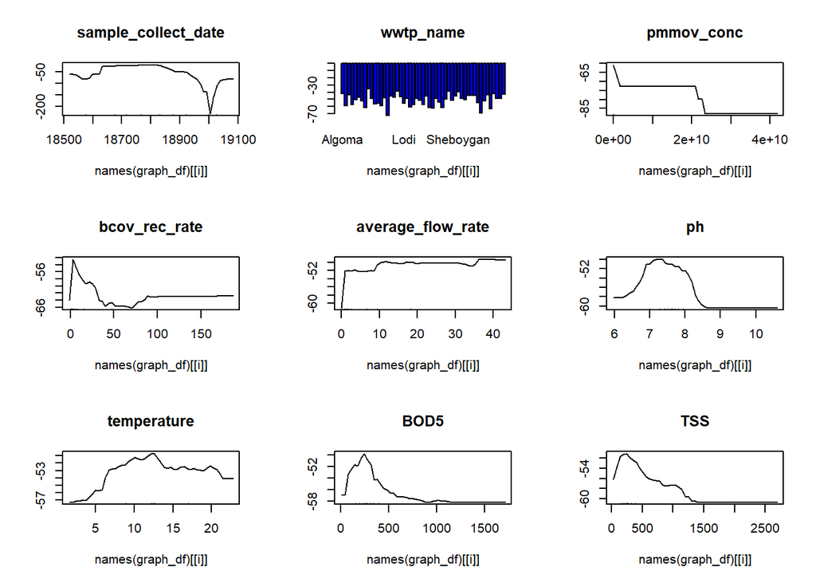

```r
graph_df <- adeline_df%>%
  na.roughfix()
num_var = length(graph_df) - 1
par(mfrow=c(3,3))
for(i in 1:(num_var)) randomForest::partialPlot(ade_mod,
                                                graph_df,
                                                x.var = names(graph_df)[[i]],
                                                main = names(graph_df)[[i]])
```

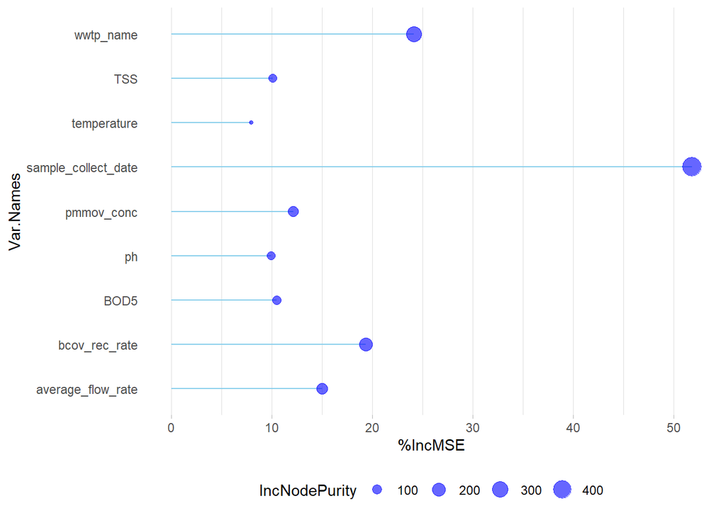

```r
resid_df <- data.select.2.sc%>%
  select(-case_rate, -avg_sars_cov2_conc, - difference.log)%>%
  select(sample_collect_date, everything())


resid_mod <- randomForest(resid ~ ., data = resid_df, ntree=100,
                    na.action = na.roughfix, importance=TRUE, keep.inbag=TRUE)
imp_ploting(resid_mod)
```

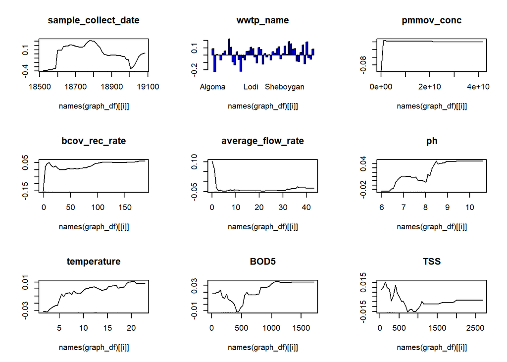

```r
graph_df <- resid_df%>%
  na.roughfix()
num_var = length(graph_df) - 1
par(mfrow=c(3,3))
for(i in 1:(num_var)) randomForest::partialPlot(resid_mod, graph_df,
                                                x.var = names(graph_df)[[i]],
                                                main = names(graph_df)[[i]])
```

Given this conclusion we can fit these residuals into a random forest model to find what the intercept should be.

This gives good results. but its assumption of a constant ratio does not match with what we expect of reality. depending on these factors we expect both a change in trend and a change in slope. This brings us to: s hypothesis 2: there is a linear relationship between N1 and cases. the covariates change the intercept and slope of the relationship.

```r
data(WasteWater_data, package = "DSIWastewater")
reg_df <- WasteWater_data%>%
  select(regions, site)%>%
  rename(wwtp_name = site)%>%
  distinct()


rand_tree_df <- data.select.2.sc%>%
  left_join(reg_df)%>%
  select(-resid, - wwtp_name)%>%#,  -date, -tests
  mutate(regions = as.factor(regions))%>%
  na.roughfix()%>%
  filter(if_all(everything(), is.finite)) # N1 + N2



Form <- case_rate ~ avg_sars_cov2_conc| . - avg_sars_cov2_conc #sars_cov2_adj_load
library(rsample)
forest_model <- random_linear_forest(data = rand_tree_df,
                                     num_tree = 20,
                  model_formula = Form,
                                     max_depth = Inf,
                  verbose = FALSE)

pred = predict(forest_model, rand_tree_df)
resid = rand_tree_df$conf_case - pred
oob_error_df <- OOB_MSE_num_trees(forest_model)

{
layout(matrix(1:4, 2, 2, byrow = TRUE))
plot(oob_error_df$num_tree, oob_error_df$model_MSE, type = "l")
hist(resid)
plot(resid, pred)
plot(x = 0:10, y = 0:10, ann = F,bty = "n",type = "n",
     xaxt = "n", yaxt = "n")

text(x = 5, y = 5, paste(show(forest_model), collapse="\n"), cex = .7)
}
```

[output not shown]

```r
inc_MSE <- gen_INCMSE(forest_model)
#reran model
#or


ggplot(inc_MSE, aes(x = var, y = incMSE)) +
  geom_segment( aes(x=var, xend=var, y = 0, yend=incMSE), color="skyblue") +
  geom_point(aes(size = old_incMSE), color="blue", alpha=0.6) +
  theme_light() +
  coord_flip() +
  theme(
    legend.position="bottom",
    panel.grid.major.y = element_blank(),
    panel.border = element_blank(),
    axis.ticks.y = element_blank()
)
inc_MSE

rand_tree_df$pred <- exp(predict(forest_model, forest_model@data))
rand_tree_df2 <- rand_tree_df%>%
  select(regions, date, pred)

B <- rand_tree_df%>%
  ggplot(aes(x = date))+
  geom_line(aes(y = log(pred), color = "red"))+
  geom_line(aes(y = conf_case))
ggplotly(B)
```

[output not shown]

```r
CaseRegressionOutput <- buildRegressionEstimateTable(DataMod = rand_tree_df2,
    RunOn = "pred",
    SplitOn = "regions", DaysRegressed = 7)%>%
  rename(site = regions)

CaseFlags2 <- CaseRegressionOutput%>%
  mutate(flag = as.numeric(lmreg_slope > 1))%>%
  select(date, flag)


CaseFlags2%>%
  select(-date)%>%
  summarise(s = sum(flag))

load("CaseFlags.Rdata")
CaseFlags%>%
  select(-date)%>%
  mutate(across(case_flag_Cases:slope_switch_flag_7DayCases, ~ ifelse(is.na(.x),0,.x)))%>%
  summarise(across(case_flag_Cases:slope_switch_flag_7DayCases, sum))

CaseFlags <- CaseFlags%>%
  select(date, case_flag_Cases)

full_data <- inner_join(CaseFlags,
                       mutate(CaseFlags2,date = as.Date(date, lubridate::mdy("1/1/1970"))))%>%
  DF_date_vector("date", c("case_flag_Cases", "flag"))



mean(date_distance_calc(full_data, "case_flag_Cases", "flag")$flag**2, na.rm = TRUE)


old_df <- date_Flag_DF%>%
  select(date, flag.ntile_90_0.9)

A <- full_data%>%
  ggplot(aes(x = date))+
  geom_point(aes(y = conf_case, x = as.Date(date, lubridate::mdy("1/1/1970"))), data = base_df)+
  geom_point(aes(y = 1.25 + as.numeric(flag)/10000, color = "tree"))+
  geom_point(aes(y = 1 + as.numeric(case_flag_Cases)/10000, color = "case"))+
geom_point(aes(y = 1.5 + as.numeric(flag.ntile_90_0.9)/10000, color = "wastewater"), data = old_df)
library(plotly)
ggplotly(A)
```

[output not shown]